# Case 31 Employees Federal Credit Union

IC11-2 Summary of Data Analysis • R1, R2, R5, and R6

Frank Renn

2026-11-10

## Purpose and sample

EFCU wants to understand low borrowing and members’ views of its services and operations. This report analyzes **R1, R2, R5, and R6** using the cleaned Module 10 dataset.

- **128 responses** are available. Percentages use each item’s valid responses.
- The case used a mail survey and a simple random sample of 300 from a membership frame of 3,531.
- Q2 and Q28–Q29 are absent from this dataset. Rate perceptions provide context for R1 and R2, but cannot establish members’ actual reasons.

## Analysis plan

| Research question | Available measures | Analysis |
| --- | --- | --- |
| **R1** Reasons for joining | Q7r Savings-rate perception | Frequencies and one-sample t-test |
| **R2** Reasons for outside borrowing | Q8r Borrowing-rate perception; Q30 Comparative rates | Frequencies and one-sample t-tests |
| **R5** Service awareness | Q13r–Q26r | Frequencies and chi-square goodness-of-fit tests |
| **R6** Operational effectiveness | Q9r–Q10r, Q11–Q12rc, Q31–Q34, Q37r | Frequencies, chi-square goodness-of-fit tests, and one-sample t-tests |

## R1 Why do people join the Credit Union?

**Descriptive statistics · Savings-rate perceptions (Q7r)**

Table 1: Q7r Savings-rate perceptions

| Response | n | Valid % |
| --- | --- | --- |
| Very low | 1 | 0.8% |
| Low | 12 | 10.2% |
| Average | 83 | 70.3% |
| High | 22 | 18.6% |
| Very high | 0 | 0.0% |

As Table 1 shows, **70.3%** of valid respondents rate savings rates as average; **18.6%** rate them high or very high.

There are 118 valid responses and 10 excluded responses.

The results do not show a clear perception of unusually high savings rates. Q2 is needed to determine whether rates actually motivated joining.

## R1 One-sample t-test

Compare the mean savings-rate rating with **3 = average**.

Table 2: Q7r Descriptive statistics

| Item | n | Mean | SD | Median | 95% CI for mean |
| --- | --- | --- | --- | --- | --- |
| Savings-rate perception | 118 | 3.07 | 0.57 | 3.0 | 2.96–3.17 |

Table 3: Q7r Two-sided one-sample t-test against 3

| Item | Mean − 3 | t | df | p |
| --- | --- | --- | --- | --- |
| Savings-rate perception | 0.07 | 1.30 | 117 | .196 |

The average rating is **3.07**, close to the scale’s average category. The test provides insufficient evidence of a difference from 3 (t(117) = 1.30, p = .196; Table 3). This does not prove that the population mean equals 3.

## R2 Why do members borrow elsewhere?

**Descriptive statistics · Two views of EFCU’s loan rates**

Table 4: Q8r Perceived borrowing rates

| Response | n | Valid % |
| --- | --- | --- |
| Very low | 1 | 0.9% |
| Low | 17 | 15.9% |
| Average | 59 | 55.1% |
| High | 26 | 24.3% |
| Very high | 4 | 3.7% |

Table 5: Q30 CU rates are lower than competitors’

| Response | n | Valid % |
| --- | --- | --- |
| Strongly disagree | 4 | 3.1% |
| Disagree | 27 | 21.1% |
| Uncertain | 59 | 46.1% |
| Agree | 33 | 25.8% |
| Strongly agree | 5 | 3.9% |

Most valid Q8r responses are **average (55.1%)**. For Q30, **46.1% are uncertain** and 29.7% agree that CU rates are lower (Table 4; Table 5).

## R2 One-sample t-tests

Table 6: Loan-rate perceptions Descriptive statistics

| Item | n | Mean | SD | Median | 95% CI for mean |
| --- | --- | --- | --- | --- | --- |
| Q8r Borrowing-rate perception | 107 | 3.14 | 0.76 | 3.0 | 2.99–3.29 |
| Q30 CU rates lower than competitors | 128 | 3.06 | 0.87 | 3.0 | 2.91–3.21 |

Table 7: Loan-rate perceptions Two-sided t-tests against 3

| Item | Mean − 3 | t | df | p | Holm p |
| --- | --- | --- | --- | --- | --- |
| Q8r Borrowing-rate perception | 0.14 | 1.91 | 106 | .058 | .117 |
| Q30 CU rates lower than competitors | 0.06 | 0.82 | 127 | .416 | .416 |

Neither mean differs significantly from 3 at .05 (Table 7). There is no clear evidence here that members see a strong rate advantage.

**Actual outside-borrowing reasons remain unanswered.** Q28 identifies outside borrowers and Q29 asks why they borrowed elsewhere; both are missing. These ratings alone cannot show that price caused borrowing decisions.

## R5 How well are members aware of services?

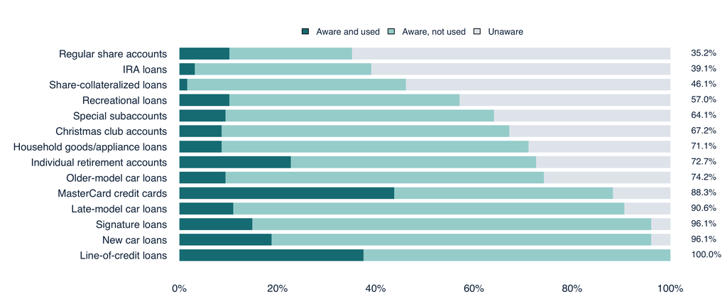

Figure 1: Awareness and use by service; the right column shows total awareness

## R5 Descriptive statistics Q13–Q19

Table 8: Service awareness and use Q13–Q19

| Item | Service | Used n (%) | Aware, not used n (%) | Unaware n (%) | Total aware |
| --- | --- | --- | --- | --- | --- |
| Q13 | Regular share accounts | 13 (10.2%) | 32 (25.0%) | 83 (64.8%) | 35.2% |
| Q14 | Special subaccounts | 12 (9.4%) | 70 (54.7%) | 46 (35.9%) | 64.1% |
| Q15 | Christmas club accounts | 11 (8.6%) | 75 (58.6%) | 42 (32.8%) | 67.2% |
| Q16 | Individual retirement accounts | 29 (22.7%) | 64 (50.0%) | 35 (27.3%) | 72.7% |
| Q17 | MasterCard credit cards | 56 (43.8%) | 57 (44.5%) | 15 (11.7%) | 88.3% |
| Q18 | Signature loans | 19 (14.8%) | 104 (81.2%) | 5 (3.9%) | 96.1% |
| Q19 | New car loans | 24 (18.8%) | 99 (77.3%) | 5 (3.9%) | 96.1% |

**Regular share accounts have the lowest awareness (35.2%).** Confirm that members understand this product name before treating this result solely as a communication problem.

## R5 Descriptive statistics Q20–Q26

Table 9: Service awareness and use Q20–Q26

| Item | Service | Used n (%) | Aware, not used n (%) | Unaware n (%) | Total aware |
| --- | --- | --- | --- | --- | --- |
| Q20 | Late-model car loans | 14 (10.9%) | 102 (79.7%) | 12 (9.4%) | 90.6% |
| Q21 | Older-model car loans | 12 (9.4%) | 83 (64.8%) | 33 (25.8%) | 74.2% |
| Q22 | Household goods/appliance loans | 11 (8.6%) | 80 (62.5%) | 37 (28.9%) | 71.1% |
| Q23 | Recreational loans | 13 (10.2%) | 60 (46.9%) | 55 (43.0%) | 57.0% |
| Q24 | Share-collateralized loans | 2 (1.6%) | 57 (44.5%) | 69 (53.9%) | 46.1% |
| Q25 | IRA loans | 4 (3.1%) | 46 (35.9%) | 78 (60.9%) | 39.1% |
| Q26 | Line-of-credit loans | 48 (37.5%) | 80 (62.5%) | 0 (0.0%) | 100.0% |

**Line-of-credit loans are universally recognized in this sample**, but only 37.5% report ever using them. Awareness and use describe different parts of the borrowing opportunity.

## R5 Chi-square goodness-of-fit tests

For each service, H₀ specifies **one-third in each awareness/use category**; Hₐ specifies at least one different proportion.

Table 10: Awareness distributions compared with equal thirds

| Service | χ² | df | p | Holm p |
| --- | --- | --- | --- | --- |
| Regular share accounts | 61.42 | 2 | < .001 | < .001 |
| Special subaccounts | 39.81 | 2 | < .001 | < .001 |
| Christmas club accounts | 48.02 | 2 | < .001 | < .001 |
| Individual retirement accounts | 16.42 | 2 | < .001 | < .001 |
| MasterCard credit cards | 26.92 | 2 | < .001 | < .001 |
| Signature loans | 134.55 | 2 | < .001 | < .001 |
| New car loans | 115.80 | 2 | < .001 | < .001 |
| Late-model car loans | 123.81 | 2 | < .001 | < .001 |
| Older-model car loans | 62.36 | 2 | < .001 | < .001 |
| Household goods/appliance loans | 56.92 | 2 | < .001 | < .001 |
| Recreational loans | 31.23 | 2 | < .001 | < .001 |
| Share-collateralized loans | 59.83 | 2 | < .001 | < .001 |
| IRA loans | 64.56 | 2 | < .001 | < .001 |
| Line-of-credit loans | 76.00 | 2 | < .001 | < .001 |

## R5 What the results mean

- **Awareness varies substantially.** It ranges from 35.2% for regular share accounts to 100.0% for line-of-credit loans (Figure 1).
- **Some recognized loans have limited use.** Signature loans are known by 96.1%, yet 14.8% have used them. New car loans show a similar gap (Table 8).
- **All 14 distributions differ from equal thirds**, including after Holm adjustment (Table 10). The direction comes from the frequencies: unawareness is not the largest category for every service.

Use targeted explanations for poorly recognized products and investigate barriers for well-known loans with low use. The survey does not establish which action will increase borrowing.

## R6 How effectively is EFCU operated?

**Descriptive statistics · Statement frequency and accuracy**

Table 11: Q9 Statement frequency

| Response | n | Valid % |
| --- | --- | --- |
| Never | 0 | 0.0% |
| Not often enough | 29 | 22.7% |
| About right | 99 | 77.3% |
| Very often | 0 | 0.0% |
| Too often | 0 | 0.0% |

Table 12: Q10 Statement accuracy

| Response | n | Valid % |
| --- | --- | --- |
| Poor | 2 | 1.6% |
| Fair | 4 | 3.1% |
| Good | 54 | 42.2% |
| Excellent | 68 | 53.1% |

Most members say statement frequency is **about right (77.3%)**, but **22.7% want statements more often** (Table 11). Statement accuracy is rated good or excellent by 95.3% (Table 12).

## R6 Understandability and confidentiality

Table 13: Yes/no operational responses

| Item | Valid n | Yes n (%) | No n (%) | Excluded |
| --- | --- | --- | --- | --- |
| Q11 Statements easy to understand | 128 | 125 (97.7%) | 3 (2.3%) | 0 |
| Q12 Account information confidential | 106 | 74 (69.8%) | 32 (30.2%) | 22 |

Statements are understandable to **97.7%** of respondents.

Confidentiality deserves follow-up: **32 of 106 valid respondents (30.2%) answer no**, while 22 responses are excluded (Table 13).

## R6 Chi-square goodness-of-fit tests

Table 14: Categorical operational responses compared with equal category proportions

| Item | n | χ² | df | p | Holm p |
| --- | --- | --- | --- | --- | --- |
| Q9 Statement frequency | 128 | 287.70 | 4 | < .001 | < .001 |
| Q10 Statement accuracy | 128 | 108.25 | 3 | < .001 | < .001 |
| Q11 Easy to understand | 128 | 116.28 | 1 | < .001 | < .001 |
| Q12 Account confidentiality | 106 | 16.64 | 1 | < .001 | < .001 |

All four distributions differ from equal category proportions, including after Holm adjustment (Table 14).

The frequencies show where responses concentrate: **about-right frequency, good/excellent accuracy, and yes on understandability and confidentiality**.

## R6 Operational ratings Descriptive statistics

Table 15: Operational ratings on their respective five-point scales

| Item | n | Mean | SD | 95% CI for mean | Favorable % |
| --- | --- | --- | --- | --- | --- |
| Q31 Financial information confidential | 128 | 3.95 | 0.68 | 3.83–4.06 | 78.1% |
| Q32 Prompt loan processing | 128 | 3.72 | 0.79 | 3.58–3.86 | 60.2% |
| Q33 Services meet needs | 128 | 3.59 | 0.68 | 3.47–3.71 | 59.4% |
| Q34 Simple loan applications | 128 | 3.46 | 0.78 | 3.32–3.60 | 57.8% |
| Q37r Overall management and operations | 121 | 4.07 | 0.73 | 3.94–4.20 | 84.3% |

Overall management is rated good/excellent by **84.3%** of valid respondents. Among Q31–Q34, confidentiality has the highest mean and simple loan applications the lowest (Table 15).

## R6 One-sample t-tests

Table 16: Operational ratings Two-sided one-sample t-tests against 3

| Item | Mean − 3 | t | df | p | Holm p |
| --- | --- | --- | --- | --- | --- |
| Q31 Financial information confidential | 0.95 | 15.74 | 127 | < .001 | < .001 |
| Q32 Prompt loan processing | 0.72 | 10.25 | 127 | < .001 | < .001 |
| Q33 Services meet needs | 0.59 | 9.87 | 127 | < .001 | < .001 |
| Q34 Simple loan applications | 0.46 | 6.66 | 127 | < .001 | < .001 |
| Q37r Overall management and operations | 1.07 | 16.13 | 120 | < .001 | < .001 |

All five mean ratings exceed their midpoint, with sufficient evidence of differences after Holm adjustment (all adjusted p < .001; Table 16). Members generally evaluate operations positively.

The positive overall assessment still leaves room to improve application simplicity and address the statement-frequency and confidentiality concerns shown in Table 11 and Table 13.

## Recommended next steps

1. **Check product understanding.** Verify the unusually low recognition of regular share accounts, then clarify names and benefits for poorly recognized services.
2. **Investigate the gap between awareness and use.** Ask members who know about signature and car loans what prevents use before choosing a campaign or pricing change.
3. **Follow up on operational concerns.** Explore statement-frequency preferences, the Q12 confidentiality concerns, and friction in loan applications.
4. **Collect the missing decision evidence.** Obtain Q2, Q28, and Q29 to answer the joining and outside-borrowing questions directly.

## Appendix Data coding and exclusions

| Variables | Coding used in this report | Exclusions |
| --- | --- | --- |
| Q7r, Q8r | 6 − original Q7/Q8; 1 = very low, 5 = very high | Original code 6 and missing values |
| Q13r–Q26r | 4 − original Q13–Q26; 1 = unaware, 2 = aware/not used, 3 = aware/used | Missing or invalid responses |
| Q9r | 6 − original Q9; 1 = never, 5 = too often | Missing or invalid responses |
| Q10r | 5 − original Q10; 1 = poor, 4 = excellent | Missing or invalid responses |
| Q11, Q12rc | 1 = yes, 2 = no | Code 3 = no answer |
| Q30–Q34 | Original agreement scores; 1–5 | Missing or invalid responses |
| Q37r | 6 − original Q37; 1 = very poor, 5 = excellent | Original code 6 and missing values |

## Appendix Valid responses and assumptions

Table 17: Items with excluded responses

| Item | Valid n | Excluded |
| --- | --- | --- |
| Q7 Savings rates | 118 | 10 |
| Q8 Borrowing rates | 107 | 21 |
| Q12 Confidentiality | 106 | 22 |
| Q37 Overall management | 121 | 7 |

- All other reported items have 128 valid responses. Missing responses are excluded item by item; no values are imputed.
- T-tests follow the class’s interval approximation for numerical rating scores. Goodness-of-fit tests retain zero-count categories and have adequate expected counts.
- Responses are treated as independent across members. Separate service tests are adjusted together using Holm’s method; R2’s two tests and each R6 test family are adjusted separately.
- The findings describe the supplied respondents. Nonresponse and the mismatch with the narrative’s sample count limit population generalization.

## Appendix Reproduce and publish

Place this QMD beside **Case 31 Data_efcu_1_cleaned.sav**. Install the packages once in the R console:

```r
install.packages(c("foreign", "knitr", "rmarkdown"))
```

Render with Quarto:

```bash
quarto render Frank_Renn_Case31_R1_R2_R5_R6.qmd
```

The project archive contains a ready-rendered HTML file and an identical `index.html` for GitHub Pages. After publication, enter the actual repository and Pages URLs in the QMD’s `params`, render again, and upload the updated HTML.

## Appendix

- [View my GitHub Pages report](https://falasol.github.io/case31/R1R2R5R6.html)
- [GithUb Repo for Case 31](https://github.com/falasol/case31)